# Ambiguity Aversion

2 May 2019

## Ellsberg's "Two-Urn Paradox" (1961)

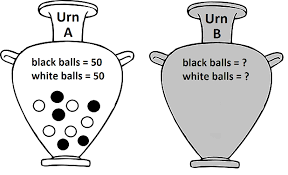

Each urn contains 100 balls.  
Every ball is either white or black.

You are to randomly draw a ball from one of these urns. If the ball is white, you win $100.  
**Which urn do you choose?**

## Some Distinctions

Risk:

- A **measurable** lack of certainty represented by numerical probabilities
- E.g., "there is a 50% chance that it will rain tomorrow"
- Urn A

Uncertainty:

- An **unmeasurable** lack of certainty
- E.g., "there is an unknown probability that it will rain tomorrow"
- Urn B

Ambiguity Aversion (AA):

- The preference for "risk" over "uncertainty", independent of utility.
- E.g. the robust finding that people, on average, prefer urn A over urn B.

## The Ambiguity Aversion Literature

- Economists showing off thier math skills trying to model AA.
- Successful, yet often narrow in focus.
- More or less confined to:
  - Contrived economic games & bets (e.g., the urns)
  - Applications in financial decisions and markets.
  - Overtly quantitative domains.
- But how does ambiguity affect other decisions that cant be easily quantified, when utility can't be easily measured?

## AA and Qualitative domains

- Very sparse literature here, but AA has been found to arise in:
  - Medical contexts
    - Choices to undergo medical procedures (Curley et. al., 1984; Bier & Connell, 1994)
    - Choices to vaccinate (Ritov & Baron, 1990)
  - Decisions on where to live (Viscusi et al., 1991)
- No systematic treatment of this (that I know of).
- This is where we come in! We want to find out:
1. Does ambiguity aversion systematically arise in qualitative ‘real-world’ situations in a variety of different contexts and scenarios?
2. Is the degree of ambiguity aversion different for gains and losses?

## Study Design

- Participants (*N* = 1200, MTurk sample) presented with one qualitative vignette.
- Then shown two different situations in relation to the vignette — one "ambiguous", one "risky".
- Asked "which of these two situations you would rather be in"
- Respond on 7-point Likert scale, coded so that 3 = Ambiguity Aversion, 0 = Neutrality, -3 = Ambiguity Seeking.
- 24 different vignettes, all of differing contexts: social, workplace, romantic, health, family etc.
- 12 "gain" vignettes, 12 "loss" vignettes.

## Examples

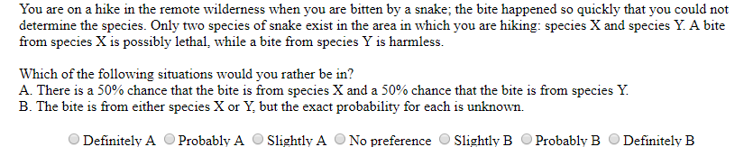

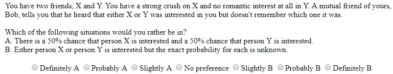

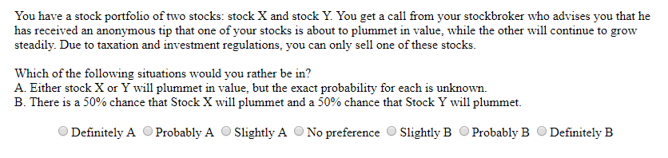

## Results

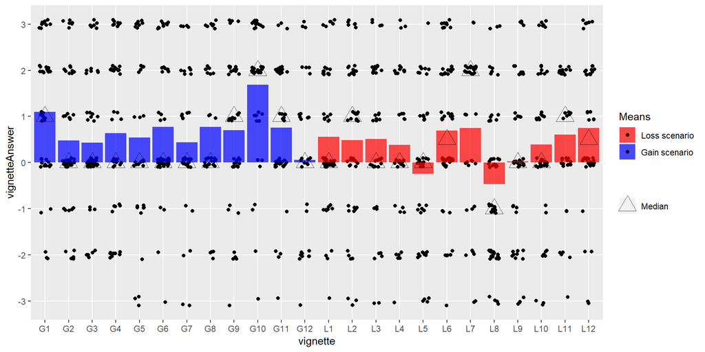

## Statistical Analyses

- We ran the following ordinal logistic regressions on this preference:
  1. No predictors. (AA overall?)
  2. Predictor including a main effect of condition, that is whether it is gain or loss. (AA modulated by gain or loss?)
  3. Predictor including a main effect of order of the option. (Ensure answer order doesn't affect responses)
  4. Predictor including a main effect of condition plus a random intercept of question.(Does AA vary by situation?)
  5. Post-hoc model with only a random effect for intercept by vignette, to see whether condition (gain or loss) predictor adds anything beyond random effect.
- Compare AIC to select best model.
- Ran both Bayesian and Frequentist versions of models.

## Freq: No Predictors

```r
olm.freq.nopred <-polr(vignetteAnswer.ordfac ~ 1, data = d_pass,
                         method = "logistic", Hess = TRUE)
summary(olm.freq.nopred)
```

```
## Call:
## polr(formula = vignetteAnswer.ordfac ~ 1, data = d_pass, Hess = TRUE,
##     method = "logistic")
##
## No coefficients
##
## Intercepts:
##       Value   Std. Error t value
## -3|-2  -3.358   0.165    -20.348
## -2|-1  -1.862   0.087    -21.352
## -1|0   -1.332   0.073    -18.199
## 0|1     0.142   0.060      2.378
## 1|2     0.716   0.063     11.298
## 2|3     2.058   0.094     21.921
##
## Residual Deviance: 3961.75
## AIC: 3973.75
```

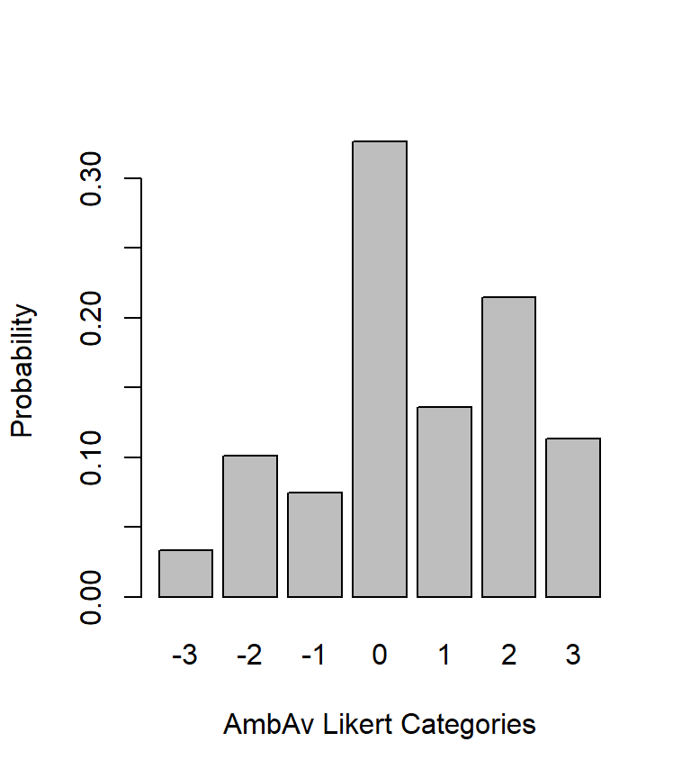

```r
#get probabilities
logistic_cdf <- function(x) {
  return( 1/(1+exp(-x) ))
}
cdf <- logistic_cdf(olm.freq.nopred$zeta)
pdf <- c(cdf[1], diff(cdf), 1 - cdf[6])
names(pdf) <- -3:3

barplot(pdf, xlab = "AmbAv Likert Categories",
             ylab = "Probability")
```

## Freq: Gain or Loss Predictor

```r
olm.freq.GLpred <-  polr(vignetteAnswer.ordfac ~ vignetteType,
                         data = d_pass, method = "logistic", Hess = TRUE)
summary(olm.freq.GLpred)
```

```
## Call:
## polr(formula = vignetteAnswer.ordfac ~ vignetteType, data = d_pass,
##     Hess = TRUE, method = "logistic")
##
## Coefficients:
##               Value Std. Error t value
## vignetteTypeG 0.361      0.106     3.4
##
## Intercepts:
##       Value   Std. Error t value
## -3|-2  -3.197   0.171    -18.668
## -2|-1  -1.696   0.099    -17.051
## -1|0   -1.162   0.088    -13.189
## 0|1     0.319   0.080      4.013
## 1|2     0.895   0.083     10.796
## 2|3     2.242   0.109     20.530
##
## Residual Deviance: 3950.19
## AIC: 3964.19
```

```r
ci <- confint(olm.freq.GLpred)
exp(cbind(OR = coef(olm.freq.GLpred), t(ci)))
```

```
##                OR 2.5 % 97.5 %
## vignetteTypeG 1.4   1.2    1.8
```

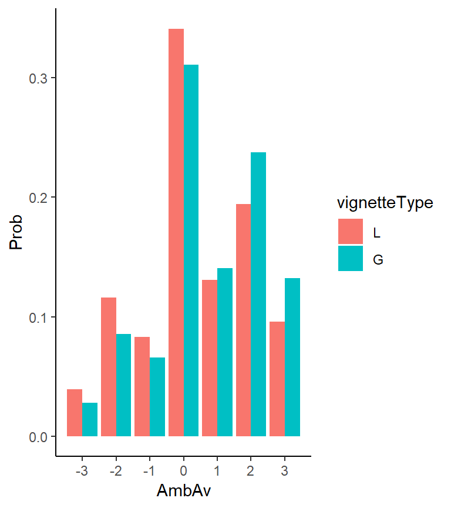

## Freq: Answer Order Predictor

```r
olm.freq.ordpred <- polr(vignetteAnswer.ordfac ~ answerOrder,
                    data = d_pass, method = "logistic", Hess = TRUE)
summary(olm.freq.ordpred)
```

```
## Call:
## polr(formula = vignetteAnswer.ordfac ~ answerOrder, data = d_pass,
##     Hess = TRUE, method = "logistic")
##
## Coefficients:
##               Value Std. Error t value
## answerOrderB -0.076      0.106  -0.719
##
## Intercepts:
##       Value   Std. Error t value
## -3|-2  -3.398   0.174    -19.512
## -2|-1  -1.901   0.103    -18.389
## -1|0   -1.371   0.092    -14.944
## 0|1     0.103   0.081      1.270
## 1|2     0.677   0.083      8.125
## 2|3     2.019   0.108     18.716
##
## Residual Deviance: 3961.24
## AIC: 3975.24
```

## Freq: Fixed Gain/Loss Effect and Random Intercept

```r
olmm.freq <- clmm(vignetteAnswer.ordfac ~ vignetteType + (1|vignette),
                  data = d_pass, link = "logit", nAGQ = 10)
summary(olmm.freq)
```

```
## Cumulative Link Mixed Model fitted with the adaptive Gauss-Hermite
## quadrature approximation with 10 quadrature points
##
## formula: vignetteAnswer.ordfac ~ vignetteType + (1 | vignette)
## data:    d_pass
##
##  link  threshold nobs logLik   AIC     niter     max.grad cond.H
##  logit flexible  1130 -1963.78 3943.56 633(1902) 3.24e-03 1.4e+02
##
## Random effects:
##  Groups   Name        Variance Std.Dev.
##  vignette (Intercept) 0.143    0.378
## Number of groups:  vignette 24
##
## Coefficients:
##               Estimate Std. Error z value Pr(>|z|)
## vignetteTypeG    0.366      0.188    1.94    0.052 .
## ---
## Signif. codes:  0 '***' 0.001 '**' 0.01 '*' 0.05 '.' 0.1 ' ' 1
##
## Threshold coefficients:
##       Estimate Std. Error z value
## -3|-2   -3.270      0.204  -16.00
## -2|-1   -1.749      0.149  -11.75
## -1|0    -1.202      0.141   -8.50
## 0|1      0.328      0.136    2.41
## 1|2      0.923      0.138    6.70
## 2|3      2.303      0.156   14.78
```

```r
ci <- confint(olmm.freq)
exp(cbind(OR = coef(olmm.freq), ci))
```

```
##                   OR 2.5 % 97.5 %
## -3|-2          0.038 0.025  0.057
## -2|-1          0.174 0.130  0.233
## -1|0           0.301 0.228  0.397
## 0|1            1.388 1.063  1.811
## 1|2            2.517 1.921  3.297
## 2|3           10.006 7.373 13.581
## vignetteTypeG  1.441 0.997  2.084
```

## Freq: Only random intercept (post-hoc)

```r
olm.freq.onlyrand <- clmm(vignetteAnswer.ordfac ~ 1 + (1|vignette), data = d_pass, link = "logit", nAGQ = 10)
summary(olm.freq.onlyrand) #posthoc - does GL add to model?
```

```
## Cumulative Link Mixed Model fitted with the adaptive Gauss-Hermite
## quadrature approximation with 10 quadrature points
##
## formula: vignetteAnswer.ordfac ~ 1 + (1 | vignette)
## data:    d_pass
##
##  link  threshold nobs logLik   AIC     niter     max.grad cond.H
##  logit flexible  1130 -1965.53 3945.06 492(1479) 4.68e-03 7.5e+01
##
## Random effects:
##  Groups   Name        Variance Std.Dev.
##  vignette (Intercept) 0.177    0.421
## Number of groups:  vignette 24
##
## No Coefficients
##
## Threshold coefficients:
##       Estimate Std. Error z value
## -3|-2   -3.452      0.188  -18.39
## -2|-1   -1.931      0.124  -15.56
## -1|0    -1.384      0.114  -12.11
## 0|1      0.146      0.105    1.39
## 1|2      0.743      0.108    6.89
## 2|3      2.124      0.129   16.48
```

## Freq: Comparing the models

The AIC values for our different models are :

- No Predictors: 3973.75
- Gain or Loss Predictor: 3964.19
- Answer order Predictor: 3975.24
- Mixed model: 3943.56 (i.e. random intercept by vignette and fixed GL Predictor)
- Only Random Intercept: 3945.06 (post-hoc)

Best model by AIC is the Mixed Model, according with the general findings in the Ambiguity Aversion literature.

## Questions, Discussion, Ideas

[figure not shown]

## References

Bier, V. M., & Connell, B. L. (1994). Ambiguity seeking in multi‐attribute decisions: Effects of optimism and message framing. Journal of Behavioral Decision Making, 7(3), 169-182.

Curley, S. P., Eraker, S. A., & Yates, J. F. (1984). An investigation of patient's reactions to therapeutic uncertainty. Medical Decision Making, 4(4), 501-511.

Ellsberg, D. (1961). Risk, ambiguity, and the Savage axioms. The quarterly journal of economics, 643-669.

Ritov, I., & Baron, J. (1990). Reluctance to vaccinate: Omission bias and ambiguity. Journal of Behavioral Decision Making, 3(4), 263-277.

Viscusi, W. K., Magat, W. A., & Huber, J. (1991). Communication of ambiguous risk information. Theory and Decision, 31(2-3), 159173.

Wang, P. A. (2011). Online Phishing in the Eyes of Online Shoppers. IAENG International Journal of Computer Science, 38(4).

## Bayesian versions

- fit same models, but bayesian! using brms packge (implemented with stan)
- results more or less the same.

The WAIC values for our different models are :

- No Predictors: 3973.7
- Gain or Loss Predictor: 3964.32
- Answer order Predictor: 3975.36
- Mixed model: 3929.29 (i.e. random intercept by vignette and fixed GL Predictor)
- Only Random Intercept: 3929.33 (post-hoc)

Again — best model is Mixed model.

## Urn vignette Analysis

Lastly, to ensure that our study replicates the existing effect with our new methodology, (using a likert response to show preference as opposed to pricing options or asking for a simple force choice preference), two of our vignettes (one for gain and one for loss) were direct replications of the urn phenomenon. For example:

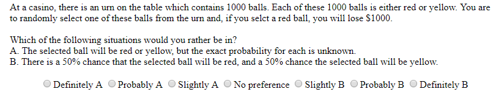

## Urn Vignette results

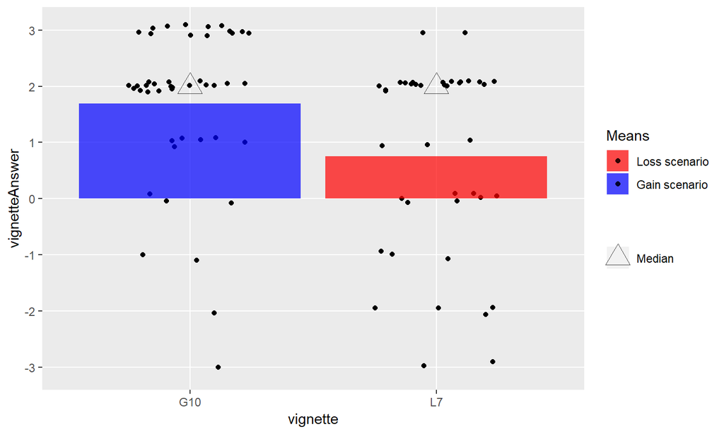

## Urn vignette Analyses

- We ran the following ordinal logistic regressions on this preference:
- No predictors.
- Predictor including a main effect of condition, that is whether it is gain or loss.

```
## Call:
## polr(formula = vignetteAnswer.ordfac ~ 1, data = d_pass_urns,
##     Hess = TRUE, method = "logistic")
##
## No coefficients
##
## Intercepts:
##       Value Std. Error t value
## -3|-2 -3.31  0.59      -5.63
## -2|-1 -2.26  0.37      -6.10
## -1|0  -1.71  0.30      -5.68
## 0|1   -0.99  0.24      -4.06
## 1|2   -0.50  0.22      -2.25
## 2|3    1.54  0.28       5.41
##
## Residual Deviance: 273.17
## AIC: 285.17
```

```
## Call:
## polr(formula = vignetteAnswer.ordfac ~ vignetteType, data = d_pass_urns,
##     Hess = TRUE, method = "logistic")
##
## Coefficients:
##               Value Std. Error t value
## vignetteTypeG   1.2      0.417    2.87
##
## Intercepts:
##       Value  Std. Error t value
## -3|-2 -2.839  0.607     -4.680
## -2|-1 -1.775  0.404     -4.395
## -1|0  -1.203  0.344     -3.491
## 0|1   -0.440  0.307     -1.436
## 1|2    0.075  0.299      0.249
## 2|3    2.261  0.395      5.726
##
## Residual Deviance: 264.55
## AIC: 278.55
```

## AIC values

The AIC values for our two different frequentist models are:

- 285.17 for the model with no predictors
- 278.55 for the model with Gain or Loss as a predictor

These values illustrate that the existing effect is replicated in our findings. Firstly, ambiguity aversion exists in both gains and loss variants of the classic urn task. Secondly, the degree of ambiguity aversion is affected by whether we are discussing domains of loss or gain — ambiguity aversion is stronger for gains than for losses.

## Bayesian

## WAIC values

- No Predictor Model: 285.59
- Gain/Loss Predictor Model: 279.23